# Understanding State Preferences With Text As Data: the 2018 update

Alexander Baturo

Dublin City University  
alex.baturo@dcu.ie

Niheer Dasandi

University of Birmingham  
n.dasandi@bham.ac.uk

Slava Jankin Mikhaylov

University of Essex  
s.mikhaylov@essex.ac.uk

21 August 2018

Abstract

This update addresses two things – changes to `quanteda` API that broke some code and additional data available that now covers the period 1970-2017.

## Reading in UNGDC

```r
#Loading packages and data
library(readtext)
library(quanteda)
library(dplyr)
library(stringr)
library(ggplot2)
library(rworldmap)
library(RColorBrewer)
library(classInt)
library(readxl)
library(ggridges)
library(viridis)
```

Zip archive with the UNGDC data will need to be downloaded and file path below pointed to the folder.

```r
#File path to UNGDC unzipped data archive
DATA_DIR <- "~/Dropbox/Research/UN Data/"
#Reading in text files
ungd_files <- readtext(paste0(DATA_DIR, "Converted sessions/*"),
                                 docvarsfrom = "filenames",
                                 dvsep="_",
                                 docvarnames = c("Country", "Session", "Year"))
#changing row.names to have only country_year, rather than folder pathway from `readtext`.
 ungd_files$doc_id <- str_replace(ungd_files$doc_id , ".txt", "") %>%
   str_replace(. , "_\\d{2}", "")
```

## Creating corpus

```r
ungd_corpus <- corpus(ungd_files, text_field = "text")
```

## UNGDC corpus summary

```r
summarise(group_by(summary(ungd_corpus, n = 7897),Year),
                           mean(Types),mean(Tokens),
                           mean(Sentences),min(Sentences),max(Sentences))
```

```
# A tibble: 48 x 6
    Year `mean(Types)` `mean(Tokens)` `mean(Sentences)` `min(Sentences)` `max(Sentences)`
   <int>         <dbl>          <dbl>             <dbl>            <dbl>            <dbl>
 1  1970         1247.          4347               169.               76              368
 2  1971         1245.          4386.              171.               70              372
 3  1972         1242.          4330.              170.               34              381
 4  1973         1260.          4472.              179.               22              485
 5  1974         1245.          4413.              171.               38              432
 6  1975         1203.          4243.              170.               35              418
 7  1976         1268.          4481.              178.               75              446
 8  1977         1229.          4330.              177.               72              448
 9  1978         1266.          4438.              179.               76              403
10  1979         1278.          4532.              184.               42              495
# ... with 38 more rows
```

## Summary of speakers

As discussed in the text we categorize speakers by:

1. heads of state or government (e.g. presidents, prime ministers, kings);
2. vice-presidents, deputy prime ministers, and foreign ministers;
3. country representative at the UN.

```r
#Reading in Excel spreadsheet with speakers information
posts <- read_excel("posts_of_speakers.xlsx")
table <- table(posts$Post)
table
```

```
Category1 Category2 Category3
     1909      2126       276
```

```r
#Proportions by category
prop.table(table)
```

```
 Category1  Category2  Category3
0.44282069 0.49315704 0.06402227
```

## Tokenizing documents

```r
#Tokenization and basic pre-processing
tok <- tokens(ungd_corpus, what = "word",
              remove_punct = TRUE,
              remove_symbols = TRUE,
              remove_numbers = TRUE,
              remove_twitter = TRUE,
              remove_url = TRUE,
              remove_hyphens = TRUE,
              verbose = TRUE,
              include_docvars = TRUE)
```

```
Starting tokenization...
...tokenizing 1 of 1 blocks
...removing URLs
...serializing tokens 65093 unique types
...total elapsed:  17.584 seconds.
Finished tokenizing and cleaning 7,897 texts.
```

## Removing some features

As part of converting original transcripts held by UN library to digital, machine-readable format, we had to OCR documents before 1994. That introduced several tokens that were compounded with digits, punctuation and other OCR errors. We are cleaning it up here with brute force purging of tokens.

```r
tok.m <- tokens_select(tok, c("[\\d-]", "[[:punct:]]", "^.{1,2}$"),
                       selection = "remove",
                    valuetype="regex", verbose = TRUE)
```

```
removed 4,405 features
```

```r
tok.r <- tokens_tolower(tok.m)
```

## Creating document feature matrix

```r
#DFM creation from tokens, removing stopwords, and stemming.
dfm <- dfm(tok.r,
           tolower = TRUE,
           remove=stopwords("english"),
           stem=TRUE,
           verbose = TRUE)
```

```
Creating a dfm from a tokens input...
   ... lowercasing
   ... found 7,897 documents, 51,749 features
   ... removed 101 features
   ... stemming features (English)
, trimmed 20411 feature variants
   ... created a 7,897 x 31,237 sparse dfm
   ... complete.
Elapsed time: 6.35 seconds.
```

```r
#Showing 100 most frequrent tokens in DFM
topfeatures(dfm, n = 100, decreasing = FALSE)
```

```
       berlintokyo      angloamerican        glasborough sovietczechoslovak
                 1                  1                  1                  1
              nang    imperialistisra              laird       americanisra
                 1                  1                  1                  1
     rogersgromyko         sovietwest        revengeseek               hich
                 1                  1                  1                  1
           redivid             xnajor    marxistleninist        noneuropean
                 1                  1                  1                  1
          bautista            alberdi              wnidi            vietmam
                 1                  1                  1                  1
               emn             snouid       antihitlerit               sqon
                 1                  1                  1                  1
         nonapplic              gbout    antiimperialist                coi
                 1                  1                  1                  1
      pmrticiputlc          largescal           watermil               iust
                 1                  1                  1                  1
         clepsydra            materia            uncouth                nar
                 1                  1                  1                  1
           ipresid             trario              fella            mildest
                 1                  1                  1                  1
            misael      aggiornamento         anglosaxon                nee
                 1                  1                  1                  1
             ttier            midsumm             perfor                unl
                 1                  1                  1                  1
             khiem             samdec         antikorean        phoenixvill
                 1                  1                  1                  1
               upi       africanasian    americanzionist          noncombat
                 1                  1                  1                  1
     briandkellogg           goodrich               jian               dubo
                 1                  1                  1                  1
            regenc              perma               nent        montecatini
                 1                  1                  1                  1
             ibidj            plywood               sime            ilswllf
                 1                  1                  1                  1
             komba              preci           peterson         welldeserv
                 1                  1                  1                  1
     latinamerican      quaisonsackey             apeopl           dumardai
                 1                  1                  1                  1
           auprinc       radhakrishna                lun            scheldt
                 1                  1                  1                  1
   zionistamerican          intraarab          henpresid     sovietegyptian
                 1                  1                  1                  1
            stowel              tarah              eilat          antisemit
                 1                  1                  1                  1
              thew            bolzano        nationalrat           trentino
                 1                  1                  1                  1
           giusepp            saragat               tbid         powergener
                 1                  1                  1                  1
  antinorthvietnam           iifitlim        millipitfnn                amh
                 1                  1                  1                  1
```

## TF-IDF weighting

Some of the least frequent terms above are due to OCR and text digitization errors. However, rather than dropping the terms arbitrarily we implement TF-IDF weighting.

```r
dfm.w <- dfm_tfidf(dfm)
```

## Wordscore estimates

Estimates are from 1971 as Russia hasn’t made a UNGD statement in 1970. We are estimating year by year separately as one albeit imperfect way to address concept drift.

```r
#Wordscore estimations by year
rusa <- data.frame()
for (i in 1971:2017) {
#Creating corpus for each year
ungdc.i <- corpus_subset(ungd_corpus, Year==i)
tok <- tokens(ungdc.i, what = "word",
              remove_punct = TRUE,
              remove_symbols = TRUE,
              remove_numbers = TRUE,
              remove_twitter = TRUE,
              remove_url = TRUE,
              remove_hyphens = TRUE,
              verbose = TRUE)
tok.m <- tokens_select(tok, c("[\\d-]", "[[:punct:]]", "^.{1,2}$"),
                       selection = "remove",
                    valuetype="regex", verbose = TRUE)
tok.r <- tokens_tolower(tok.m)
dfm <- dfm(tok.r,
           tolower = TRUE,
           remove=stopwords("english"),
           stem=TRUE,
           verbose = TRUE)
#tfidf weighting
dfm.w <- dfm_tfidf(dfm)
#Reference scores
refscores <- rep(NA,nrow(dfm.w))
refscores[dfm.w@docvars$Country=="RUS"] <- -1
refscores[dfm.w@docvars$Country=="USA"] <- 1
#Wordscore model
ws <- textmodel_wordscores(dfm.w, refscores, scale="linear", smooth=1)
wordscore <- predict(ws, rescaling="none")
#Writing the results into data frame
wordscores.i <- data.frame(cbind(docvars(ungdc.i), wordscore))
rusa <- rbind(rusa,wordscores.i)
}
```

[output not shown]

[output cut: 697 more lines]

[output not shown]

## Map with 2014 wordscore results

```r
sPDF <- joinCountryData2Map(subset(rusa, Year==2014),
                            joinCode="ISO3",nameJoinColumn="Country")
```

```
192 codes from your data successfully matched countries in the map
2 codes from your data failed to match with a country code in the map
51 codes from the map weren't represented in your data
```

```r
new_world <- subset(sPDF, continent != "Antarctica")
#Setting up class intervals for continuous variable
classInt <- classIntervals(sPDF$wordscore,
                           style="kmeans")
```

```
var has missing values, omitted in finding classes
```

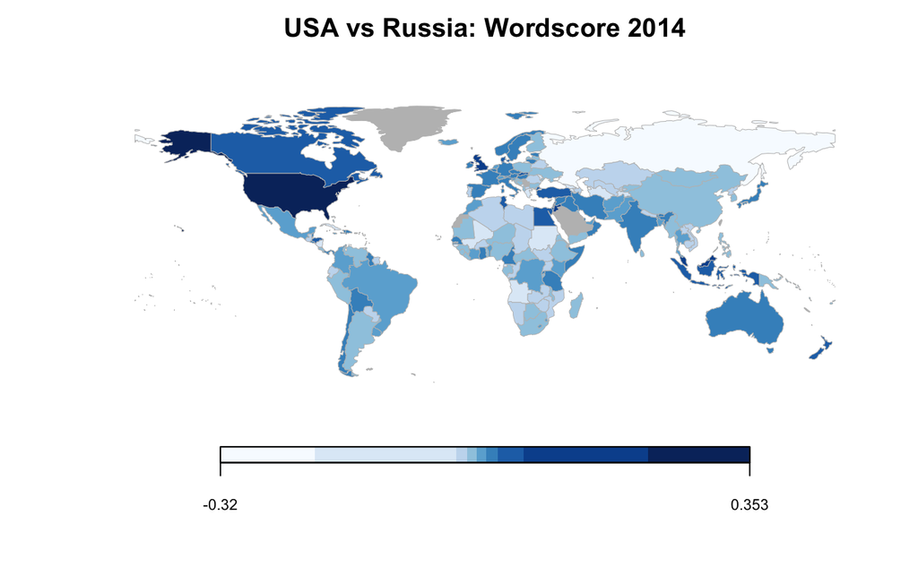

```r
catMethod=classInt$brks
#Selecting diverging palette
colourPalette <- brewer.pal(9,"Blues")
#Drawing the map
mapParams <- mapCountryData(new_world,nameColumnToPlot="wordscore",
                            catMethod=catMethod,
                            mapTitle="USA vs Russia: Wordscore 2014",
                            colourPalette=colourPalette,
                            missingCountryCol="grey",
                            addLegend="FALSE")
#adding legend
do.call( addMapLegend, c( mapParams, legendLabels="limits",
                          labelFontSize=0.7,legendShrink=0.7,
                          legendMar=4, legendWidth=0.6))
```

## France and Germany on the RUS-USA dimension

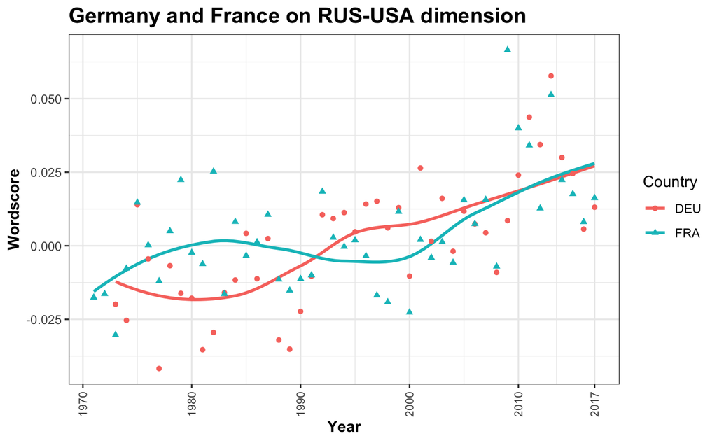

```r
ggplot(data=subset(rusa,Country=="FRA"| Country == "DEU"),
            aes(x=Year, y=wordscore, group=Country, colour=Country)) +
  theme_bw() +
  ggtitle("Germany and France on RUS-USA dimension") + ylab("Wordscore")+
  theme(plot.title = element_text(lineheight=.8, face="bold", size=15),
        axis.title.x = element_text(face="bold", size=11),
        axis.title.y = element_text(face="bold", size=11),
        axis.text.x  = element_text(angle=90, vjust=0.5, size=8)) +
  scale_y_continuous() +
  scale_x_continuous(breaks = c(1970, 1980, 1990, 2000, 2010, 2017)) +
  geom_smooth(se = FALSE) +
  geom_point(aes(shape=Country))
```

## Changes in position density over time

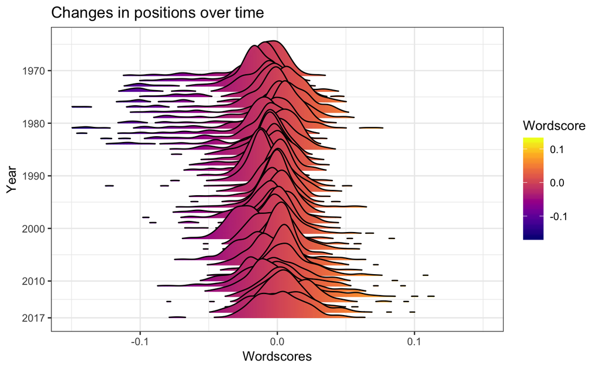

```r
ggplot(rusa, aes(x=wordscore, y=Year, group = Year,  fill = ..x..)) +
  geom_density_ridges_gradient(rel_min_height = 0.01, scale = 10) +
  scale_fill_viridis(name = "Wordscore", option = "C", alpha = .6) +
  theme_bw() + xlim(-0.15,0.15) + xlab("Wordscores")  +
  scale_y_continuous(trans = "reverse", breaks = c(1970, 1980, 1990, 2000, 2010, 2017)) +
  ggtitle("Changes in positions over time")
```